# 20.10. Индивидуальная КТ и выбранное положение боковых сборок C01

Текущая версия содержит геометрию и обоснование фиксированного положения **C01** для сравнительной ветки. Все активные сравнения используют эту позу. Полные ранние расчёты других положений сохранены в архиве; они не участвуют в текущем восстановлении сопротивлений. Исторические номера разделов сохранены для устойчивости ссылок.

При фиксированном C01 геометрические сокращения определяются в 20.13, проверяются в 20.14 и сравниваются вместе в **20.16**. В 20.17 раскрыты методы полупространства. На этом этапе восстанавливаются базовые сопротивления; пульсовая задача отложена.

Сохранённый поиск раздела 20 устанавливает происхождение C01 и ограничения выбора. Его вычисления при прежних фиксированных сопротивлениях не заменяют новый двухтканный расчёт и не означают, что положение оптимально при совместной оценке сопротивлений. Новый перебор положений здесь не запускается.

Индивидуальная КТ получена на вдохе. Положение сборок **C01** выбрано в 20.10: центр $(-187{,}500;\ 31{,}051;\ -138{,}051)$ мм, угол $14^\circ$. Ось $s$ направлена вдоль сборки, $t$ — поперёк неё, $d$ — внутрь тела по нормали в центре. Направленная центральная толщина кожа–лёгкое равна **67,00 мм**, кратчайшее расстояние от центра до лёгочной поверхности — **51,02 мм**. Это разные геометрические величины. C01 является условным кандидатом поиска при ранее фиксированных сопротивлениях; его совпадение с фактической наклейкой и совместная оптимальность положения и сопротивлений не доказаны.

Две ткани заданы действительными скалярными сопротивлениями: $\rho_1$ — весь внелёгочный фон, $\rho_2$ — лёгкое. В фон включены мышцы, жир, кости, сердце и поддиафрагмальные ткани. Это принятое двухтканное допущение, а не утверждение о равенстве реальных свойств этих тканей. Геометрия определяется по КТ до подгонки сопротивлений. В основном обратном расчёте она фиксирована; $h$ пока не восстанавливается.

Размеры сборок: **50, 60, 70, 80, 90, 110, 120, 130 и 140 мм**. Размер 100 мм исключён у этого добровольца как дубликат 90 мм. Пространственные FEM-модели используют одну сетку тела — 153 415 узлов, 721 943 тетраэдра — и одинаковые точечные контакты в её узлах. В полупространстве узлы проецируются на плоскость кожи с сохранением $s,t$; максимальное перемещение равно 12,77 мм. Два аналитических контроля используют номинальные точки на прямой. Сравнение полупространства с КТ включает изменение наружной границы и перенос контактов. Только сравнение FEM-масок между собой полностью сохраняет наружную геометрию и контакты.

## 1. Физическая постановка и математическая модель

### 1.1. Квазистатическое приближение и материальные свойства

Расчётная область представляет проводящий объём тела, ограниченный наружной поверхностью. Предполагаются линейность электрического отклика, отсутствие внутренних источников задаваемого измерительного тока и кусочная однородность материальных свойств. Рабочая частота конфигурации составляет 50 кГц. Переход к квазистатике исключает необходимость моделировать распространение электромагнитной волны в рассматриваемой постановке, но сам по себе не устраняет диэлектрическую составляющую проводимости.

В общем гармоническом случае уравнение записывается через комплексную удельную проводимость:

$$ \nabla\cdot(\gamma\nabla\psi)=0,\qquad \gamma=\sigma+\mathrm i\omega\varepsilon,\qquad \omega=2\pi f, $$ где $\psi$ — комплексная амплитуда потенциала, В; $\gamma$ — комплексная удельная проводимость, См/м; $\sigma$ — её активная составляющая, См/м; $\varepsilon$ — абсолютная диэлектрическая проницаемость, Ф/м; $f$ — частота, Гц; $\omega$ — круговая частота, с$^{-1}$; $\mathrm i$ — мнимая единица; $\nabla$ — оператор пространственного дифференцирования.

В исполняемом расчёте принято дополнительное **скалярное вещественное приближение**: используется активная проводимость, равная обратному удельному сопротивлению. Фаза, частотная дисперсия и анизотропия не идентифицируются. Это ограничивает физический смысл найденных параметров условиями данного расчёта.

Двухтканное поле проводимости определяется следующим образом:

$$ \sigma(\mathbf x)= \begin{cases} 1/\rho_2,&\mathbf x\in\Omega_{\mathrm{л}},\\ 1/\rho_1,&\mathbf x\in\Omega\setminus\Omega_{\mathrm{л}}, \end{cases} \qquad \rho_1>0,\quad\rho_2>0, $$ где $\mathbf x$ — пространственная координата, м; $\Omega$ — весь расчётный объём тела; $\Omega_{\mathrm{л}}$ — лёгочная область; $\rho_1$ и $\rho_2$ — удельные сопротивления внелёгочного фона и лёгочной области, Ом·м; $\sigma$ — удельная проводимость, См/м.

Текущее сравнение использует два материала. Историческая многотканная постановка сохранённого поиска отдельно описана в разделе 20 и служит только происхождением фиксированной позы.

### 1.2. Условия на внутренних и наружной границах

На идеальном контакте двух тканевых областей непрерывны потенциал и нормальная составляющая проводимого тока:

$$ \psi_1=\psi_2,\qquad \sigma_1\nabla\psi_1\cdot\mathbf n_{12} =\sigma_2\nabla\psi_2\cdot\mathbf n_{12}, $$ где индексы 1 и 2 обозначают значения с двух сторон границы; $\psi_j$ — потенциал, В; $\sigma_j$ — проводимость, См/м; $\mathbf n_{12}$ — одна и та же выбранная единичная нормаль к границе. Использование общей нормали необходимо для согласования знака потока.

На поверхности тела вне электродов задаётся отсутствие нормального тока. Для расчётов с конечными площадками используется полная электродная модель, учитывающая конечную площадь и контактное сопротивление [Staboulis и Dardé](https://arxiv.org/abs/1312.4202):

$$ \psi+z_\ell\sigma\frac{\partial\psi}{\partial n}=U_\ell \quad\text{на }E_\ell,\qquad \int_{E_\ell}\sigma\frac{\partial\psi}{\partial n}\,dS=I_\ell, \qquad \sum_\ell I_\ell=0, $$ где $E_\ell$ — поверхность электрода с номером $\ell$; $U_\ell$ — его постоянный потенциал, В; $z_\ell$ — удельный контактный импеданс, Ом·м²; $I_\ell$ — заданный ток, А, положительный при вводе в тело; $n$ — внешняя нормаль тела; $dS$ — элемент площади, м²; $\psi$ и $\sigma$ определены выше. Физическая плотность тока равна $-\sigma\nabla\psi$, поэтому выбранный знак $I_\ell$ согласован с током, входящим в область.

Потенциал определён с точностью до общей константы. Для единственности решения задаётся опорный потенциал либо условие нулевой суммы электродных потенциалов. Измеряемые разности не должны зависеть от допустимого выбора этой константы. Нулевой суммарный ток измерительного электрода не означает тождественно нулевой локальный ток в каждой точке его поверхности: металлический контакт остаётся эквипотенциальным.

### 1.3. Геометрия сборки и измеряемый функционал

Номинальное положение четырёх центров строится относительно общего центра и касательной оси, после чего точки проецируются на наружную поверхность:

$$ \widetilde{\mathbf r}_e=\mathbf c+q_eL\mathbf a_\varphi, \qquad \mathbf r_e=\Pi_{\partial\Omega}(\widetilde{\mathbf r}_e), \qquad (q_A,q_M,q_N,q_B)=(-1/2,-1/4,1/4,1/2), $$ где $\mathbf c$ — общий центр, $L$ — номинальное расстояние между токовыми электродами, $\mathbf a_\varphi$ — единичная касательная ось после поворота на угол $\varphi$, $q_e$ — безразмерное смещение электрода, $\Pi_{\partial\Omega}$ — проекция на поверхность тела, $A,B$ — токовые, $M,N$ — измерительные электроды. Геометрия хранится в миллиметрах и переводится в метры перед решением уравнений.

Расчётный передаточный импеданс равен

$$ Z=\frac{U_M-U_N}{I},\qquad (I_A,I_M,I_N,I_B)=(I,0,0,-I), $$ где $Z$ измеряется в омах; $U_M,U_N$ — потенциалы измерительных электродов, В; $I$ — амплитуда задаваемого тока, А. В линейном решателе используется нормировка на 1 А; она не является утверждением о токе экспериментального прибора.

Номинальная контактная площадь одного электрода составляет около 70,69 мм² и задана как 90 % площади диска диаметром 10 мм. Контактный импеданс принимается одинаковым для всех площадок. Фактическая площадь дискретного электрода определяется индуцированными граничными гранями и проверяется отдельно. Указанные контактные характеристики являются входными допущениями.

### 1.4. Слабая форма и контроль физических тождеств

При положительных проводимостях и контактных импедансах слабая форма имеет вид

$$ \int_\Omega\sigma\nabla\psi\cdot\nabla v\,dV +\sum_\ell\frac1{z_\ell}\int_{E_\ell}(\psi-U_\ell)(v-V_\ell)\,dS =\sum_\ell I_\ell V_\ell, $$ где $v$ и $V_\ell$ — пробные объёмный и электродные потенциалы; $dV$ — элемент объёма, м³; остальные величины определены в предыдущих подпунктах. Совместная фиксация опорного уровня устраняет постоянную нулевую моду системы.

Подстановка решения в качестве пробной функции даёт неотрицательную суммарную мощность диссипации. Симметрия билинейной формы приводит к взаимности при перестановке токовой и измерительной пар. Эти свойства проверяют согласованность прямого оператора. Они не устанавливают точность сегментации и не доказывают, что найденные эффективные сопротивления являются истинными свойствами тканей. Знак отдельного передаточного импеданса определяется монтажом; его нельзя отождествлять со знаком полной рассеиваемой мощности.

## 2. Геометрия по КТ

Ручная сегментация на вдохе определяет наружное тело и лёгкое. Центр, ортонормированный базис, сетка и контакты C01 зафиксированы единым контрактом. Геометрические иллюстрации ниже используют сохранённые поверхности и контакты; карта поиска и продольное сечение имеют разные задачи. Результаты КТ не являются независимым измерением сопротивлений тканей.

## 3.1. Фактически заданная область поиска и выполненная её часть

Для чтения последующих результатов сначала необходимо отделить область, в которой поиск был задан, от положений, для которых сохранился допустимый расчёт. Здесь используется тот же остановленный перебор, который анализируется в разделе 20:

$$u\in[-80,80]\ \mathrm{мм},\qquad v\in[-120,120]\ \mathrm{мм},\qquad \varphi\in[-20^\circ,20^\circ],$$

где $u,v$ — координаты параметрической сетки поиска, мм; $\varphi$ — угол поворота сборки, градусы.

Шаги равны 1 мм по каждой координате и 1° по углу. Это 161 × 241 = 38 801 параметрический центр и 1 590 841 поза «центр–угол». Координаты $u,v$ задают сетку поиска; физическое положение центра после проекции на кожу задаётся сохранёнными координатами $x,y,z$. На рисунке используются именно эти координаты. Повторного проецирования на ближайшие вершины STL нет. Различные узлы параметрической сетки могут совпадать в пространстве.

Для 475 090 поз сохранён электрический расчёт; 95 192 отклонены проверкой геометрии контактов, 216 918 исключены маской поверхности, а 803 641 ещё не проверены. В последней категории нет данных об ошибке импеданса. Поэтому вся заданная область не может считаться исследованной.

На обеих панелях показаны статусы при одном угле $\varphi=14^\circ$. Левая панель представляет параметрическую сетку, правая — те же центры в координатах КТ. Для других углов допустимость контактов может изменяться. Таблица после рисунка относится ко всем 41 углу; её числа не являются числом точек отдельной панели.

Звезда обозначает C01: $u=13$ мм, $v=-55$ мм, $\varphi=14^\circ$, центр $(-187{,}5;\ 31{,}051379;\ -138{,}051379)$ мм. Это минимум ошибки относительно эксперимента среди рассчитанных допустимых поз при фиксированных сопротивлениях. Совпадение с фактической наклейкой электродов и оптимальность при совместном изменении сопротивлений не установлены. Проверка минимума и его устойчивости приведена в разделе 20.

После фиксации C01 рассматривается анатомия в продольной плоскости сборки.

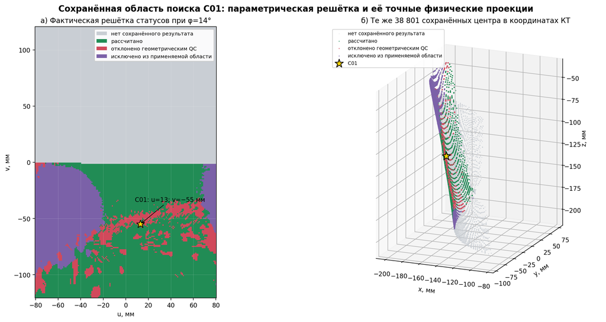

**Рисунок 3.3. Одна сохранённая область поиска в параметрических и физических координатах.** Слева показаны статусы узлов $(u,v)$ при $\varphi=14^\circ$; справа — их сохранённые проекции в системе КТ. Все координатные оси выражены в миллиметрах. Цвет обозначает категорию расчёта, а не ошибку импеданса: зелёный — рассчитанная поза, красный — отказ проверки контактов, фиолетовый — исключение маской поверхности, серый — отсутствие выполненной проверки.

Полезно сопоставлять границы цветных областей и положение звезды C01. Форма облака справа возникает при отображении параметрической сетки на поверхность тела; она не задаёт новую область поиска. Совпадающие проекции накладываются друг на друга. Ни цвет, ни плотность точек не являются вероятностью положения или картой чувствительности. В разделе 20 используется эта же сетка, но цветом показаны электрические критерии и, в некоторых панелях, минимум по углам.

**Проверка входа рисунка.**

| параметр | диапазон / размер | смысл |
| --- | --- | --- |
| u | -80 … 80 мм | 161 значение, шаг 1 мм |
| v | -120 … 120 мм | 241 значение, шаг 1 мм |
| φ | -20 … 20° | 41 значение, шаг 1° |
| центры | 38801 | точные сохранённые проекции |
| позы | 1 590 841 | полная решётка «центр–угол» |

| статус | число поз |
| --- | --- |
| нет сохранённого результата | 803641 |
| рассчитано | 475090 |
| отклонено геометрическим QC | 95192 |
| исключено из применяемой области | 216918 |

## 4. Продольное сечение по контактам текущей сборки C01

После задания области поиска необходимо проверить, как выбранная сборка располагается относительно кожи и лёгкого. Для этого строится один продольный срез по четырём сохранённым центроидам конечных контактов сборки $L=140$ мм. Это контакты численной CEM-модели; независимое измерение их фактического положения на теле отсутствует.

Четыре центроида на кривой поверхности не обязаны лежать в одной плоскости. Поэтому правило построения задаётся явно. Пусть $\mathbf r_{I+}$ и $\mathbf r_{I-}$ — центроиды токовых контактов. Выбираются середина хорды и единичное направление от $I-$ к $I+$:

$$ \mathbf p=\frac{\mathbf r_{I+}+\mathbf r_{I-}}2,\qquad \mathbf a_0=\frac{\mathbf r_{I+}-\mathbf r_{I-}} {\|\mathbf r_{I+}-\mathbf r_{I-}\|}, $$ где $\mathbf p$ — середина хорды токовых контактов, мм; $\mathbf a_0$ — единичное направление этой хорды.

Для четырёх контактов сохранены локальные наружные нормали кожи $\mathbf n_e$. Их среднее задаёт направление внутрь $\mathbf b$. Проекция хорды на перпендикулярное ему направление задаёт продольную ось $\mathbf a$:

$$ \mathbf b=-\frac{\sum_e\mathbf n_e}{\|\sum_e\mathbf n_e\|},\qquad \mathbf a=\frac{\mathbf a_0-(\mathbf a_0\cdot\mathbf b)\mathbf b} {\|\mathbf a_0-(\mathbf a_0\cdot\mathbf b)\mathbf b\|},\qquad \mathbf n_\Pi=\mathbf a\times\mathbf b, $$ где $\mathbf a,\mathbf b$ — единичные продольная и направленная внутрь оси среза; $\mathbf n_\Pi$ — единичная нормаль к плоскости; $\mathbf n_e$ — локальная наружная нормаль кожи у контакта $e$.

Плоскость натянута на хорду токовых контактов и среднее направление внутрь. Усреднение локальных нормалей — выбранное правило визуализации, а не независимое измерение нормали всей грудной стенки. Координаты среза обозначены $\tilde s,\tilde d$, чтобы отличить их от расчётного базиса $s,t,d$ в 20.16:

$$\mathbf r_\Pi=\mathbf p+\tilde s\,\mathbf a+\tilde d\,\mathbf b,\qquad \ell_e=(\mathbf r_e-\mathbf p)\cdot\mathbf n_\Pi,$$

где $\tilde s,\tilde d$ — координаты в плоскости среза, мм; $\mathbf r_\Pi$ — точка этой плоскости; $\mathbf r_e$ — центроид контакта; $\ell_e$ — знаковое расстояние центроида до плоскости, мм. Для $I+$ и $I-$ оно равно нулю по построению. Для потенциальных контактов получено $\ell(V+)=+0{,}332$ мм и $\ell(V-)=-1{,}819$ мм. Максимальное абсолютное отклонение равно 1,819 мм. Следовательно, изображать все четыре контакта как точно лежащие в срезе было бы неправильно.

В трёхмерной панели показаны центроиды, их проекции и плоскость. На двумерной панели цветные точки являются проекциями центроидов; контуры получены пересечением исходных STL-поверхностей этой плоскостью. Сердце и кости оставлены как анатомические ориентиры. В двухтканной электрической постановке они входят в общий фон $\rho_1$, а лёгкое имеет $\rho_2$.

Начало и направления этого иллюстративного среза отличаются от расчётного базиса 20.16. Подписанные расстояния относятся только к лучам данного рисунка. Направленная центральная толщина $h(0)=67{,}00$ мм, маски, контакты и рассчитанные импедансы 20.16 сохраняются. По срезу можно увидеть геометрическую неоднородность, но точность её электрического приближения проверяется отдельным сравнением операторов в разделе 11.4.

### 4.1. Что сечение позволяет установить

Плоскость через токовые контакты позволяет сопоставить продольное изменение анатомических границ и проверить отклонения потенциальных контактов. Она не описывает поперечную форму лёгкого и не задаёт область чувствительности. Электрическое сравнение должно использовать объёмные маски и согласованные условия на электродах.

Все варианты обратного восстановления сведены в 20.16.

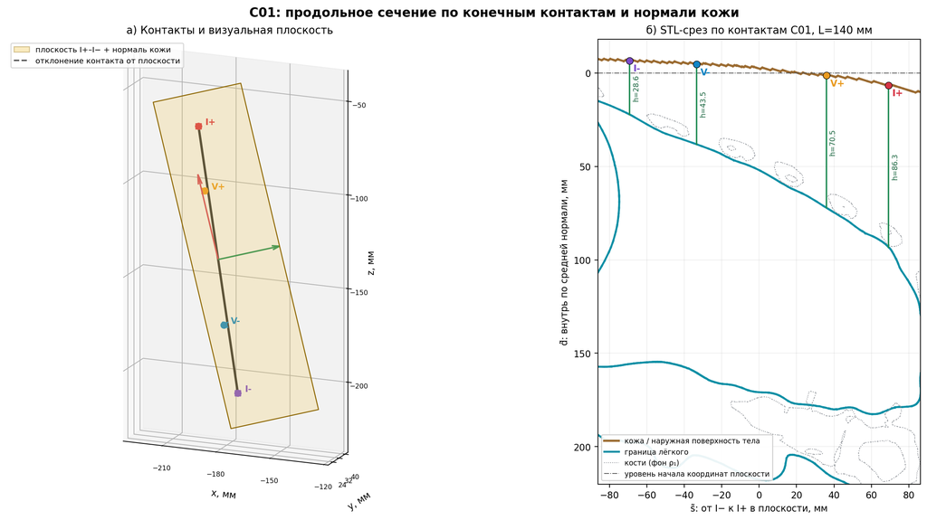

**Рисунок 4.1. Продольная плоскость и пересечение анатомических поверхностей для C01, $L=140$ мм.** Слева показаны центроиды конечных контактов, плоскость через токовые контакты и её локальные направления; пунктир соединяет потенциальные контакты с проекциями. Справа представлены контуры кожи, лёгкого, сердца и костей в этой же плоскости. Ось $\tilde s$ направлена от $I-$ к $I+$ после ортогонализации; $\tilde d$ — внутрь по средней локальной нормали. Координаты и подписанные расстояния выражены в миллиметрах.

Зелёные отрезки показывают расстояние от кожи до первого пересечения лёгкого вдоль выбранного направления. Следует сравнивать эти расстояния вдоль сборки и обращать внимание на дополнительные пересечения замкнутого лёгочного объёма. Одно постоянное $h$ такую геометрию полностью не описывает. Вместе с тем расстояние кожа–лёгкое может включать кости и другие ткани; оно не является измерением толщины одних мышц.

Отклонение потенциальных контактов от плоскости достигает 1,819 мм; это свойство сохранённой модели контактов, а не оценка ошибки экспериментальной наклейки. По одной плоскости нельзя установить распределение тока или величину вклада органов. Поэтому срез обосновывает геометрический вопрос, а ответ о точности импеданса и обратного восстановления требует последующих электрических расчётов.

Для чтения контактов слева показан небольшой фрагмент плоскости. Справа изображён участок до глубины 220 мм; нижний край окна является только границей изображения и не означает окончания лёгкого или расчётной области.

**Отклонения центроидов от визуальной плоскости.**

| электрод | s̃, мм | d̃, мм | ℓ, мм | abs(ℓ), мм |
| --- | --- | --- | --- | --- |
| I+ | 69.178 | 6.579 | -0.000 | 0.000 |
| V+ | 35.968 | 1.272 | +0.332 | 0.332 |
| V- | -33.386 | -4.665 | -1.819 | 1.819 |
| I- | -69.178 | -6.579 | +0.000 | 0.000 |

Максимум |ℓ| = **1.819 мм**; h(0) расчётной модели = **67.00 мм** и не изменён.

## 11. Аналитические представления и сопоставление прямых моделей

В этом разделе сравниваются две разные операции. Аналитическая модель заменяет пространственную анатомию идеализированной краевой задачей и поэтому уменьшает число геометрических переменных. Пространственная модель решает общую краевую задачу в объёме; конкретная форма границ и представление контактов задаются явно. Сначала сравнение проводится при известных одинаковых сопротивлениях; только после этого обсуждается, как ошибка прямого приближения может повлиять на обратное восстановление параметров.

### 11.1. Плоская двухслойная среда

Первая аналитическая модель состоит из плоского слоя фонового материала конечной толщины и нижнего лёгочного полупространства. Верхняя поверхность изолирована вне точечных электродов. Границы параллельны, среда бесконечна в горизонтальных направлениях, свойства внутри каждого слоя постоянны и изотропны. Это определённая краевая задача, для которой существует представление через ряд изображений источника.

Для единичного тока поверхностная функция Грина имеет вид

$$ G(r;h)=\frac{\rho_1}{2\pi}\left[\frac1r+2\sum_{n=1}^{\infty}\frac{k^n}{\sqrt{r^2+(2nh)^2}}\right], \qquad k=\frac{\rho_2-\rho_1}{\rho_2+\rho_1}, $$ где $G$ — потенциал на единицу тока, Ом; $r$ — поверхностное расстояние от источника, м; $h$ — толщина верхнего слоя, м; $\rho_1,\rho_2$ — сопротивления верхнего и нижнего материалов, Ом·м; $k$ — безразмерный коэффициент отражения; $n$ — номер изображения. При положительных сопротивлениях абсолютное значение коэффициента отражения меньше единицы.

Первое слагаемое описывает полусферическое растекание тока в однородном полупространстве. Последующие слагаемые возникают из условий непрерывности потенциала и тока на плоской границе двух материалов. Их геометрический смысл связан с источниками, расположенными на глубинах, кратных удвоенной толщине. В вычислении используется конечное число членов; точность усечения зависит от тканевого контраста и соотношения расстояния и толщины.

Для симметричной сборки передаточный импеданс определяется четырьмя вкладами:

$$ Z=G_{AM}-G_{BM}-G_{AN}+G_{BN} =\frac{\rho_1}{\pi}\left[\mathcal F(L/4,h)-\mathcal F(3L/4,h)\right], $$ где $G_{pq}=G(|s_p-s_q|;h)$; $A,B$ — токовые, $M,N$ — измерительные электроды; $s_p$ — их номинальные координаты; $L$ — размер сборки, м; $\mathcal F$ — выражение в квадратных скобках предыдущей формулы, м$^{-1}$; $Z$ измеряется в омах.

При равенстве сопротивлений коэффициент отражения обращается в нуль и получается контрольный предел:

$$ Z_{\mathrm{одн}}=\frac{8\rho}{3\pi L}, $$ где $\rho=\rho_1=\rho_2$ — общее удельное сопротивление, Ом·м; $L$ — расстояние между токовыми электродами, м. При неограниченном увеличении верхней толщины наблюдается однородный предел верхнего материала; при исчезновении верхнего слоя — нижнего. Для численной проверки предела очень тонкого слоя необходимо контролировать сходимость ряда отдельно.

Для C01 отдельно проверяются направленная центральная глубина 67,00 мм и кратчайшее расстояние 51,02 мм. Их подстановка в плоскую формулу является двумя разными геометрическими допущениями.

### 11.2. Пространственный вычислительный референс

КТ-референс текущего сравнения сохраняет наружное тело и исходное лёгкое при двух материалах. Точечные и конечные контакты рассматриваются раздельно. Различие полупространства и КТ включает изменение наружной границы и перевод контактов; его нельзя целиком приписывать форме лёгкого.

### 11.3. Приближение с переменной глубиной до лёгкого

Визуальное выпрямление кожи выполняется вычитанием её глубинной координаты. Полученный профиль описывает расстояние между контурами, но сохраняет только одну координату вдоль сборки. Для каждой пары электродов вводится средняя глубина:

$$ \overline h_{pq}=\frac1{\ell_{pq}}\int_{s_<}^{s_>}h_{\mathrm{апр}}(s)\,ds, \qquad \ell_{pq}=|s_p-s_q|,\quad s_<=\min(s_p,s_q),\quad s_>=\max(s_p,s_q), $$ где $p,q$ обозначают токовый и измерительный электроды; $h_{\mathrm{апр}}$ — табличный профиль расстояния по КТ; $s$ — продольная координата; $\ell_{pq}$ — длина интервала усреднения. Все длины в этой формуле должны использовать одну единицу; перед вычислением потенциала они переводятся в метры.

Приближённый импеданс вычисляется как

$$ Z_{\overline h}=G(\ell_{AM};\overline h_{AM})-G(\ell_{BM};\overline h_{BM}) -G(\ell_{AN};\overline h_{AN})+G(\ell_{BN};\overline h_{BN}), $$ где $G$ — функция Грина плоской двухслойной среды; остальные обозначения определены выше. Для постоянного профиля выражение совпадает с обычной двухслойной формулой. При переменном профиле каждая пара получает собственную плоскую задачу; единого трёхмерного распределения потенциала для всех этих подстановок не строится.

Арифметическое усреднение вдоль интервала не означает, что ток течёт вдоль прямого отрезка между электродами. Веса этого усреднения не выведены из пространственной чувствительности. Метод является эвристическим способом уменьшения размерности геометрического описания и требует проверки по прямому оператору.

Существует другая эвристика: усреднять потенциал локальной плоской модели, сохраняя расстояние между данной парой:

$$ \overline G_{pq}=\frac1{\ell_{pq}}\int_{s_<}^{s_>}G(\ell_{pq};h_{\mathrm{апр}}(s))\,ds, $$ где $\overline G_{pq}$ — усреднённое парное ядро, Ом; $\ell_{pq},s_<,s_>,h_{\mathrm{апр}}$ определены выше. Среднее функции и функция среднего в общем случае различаются вследствие нелинейности зависимости от толщины. Обе схемы сравниваются численно, однако ни одна не обеспечивает выполнения условий на исходной кривой границе.

Точное выпрямление геометрии требует преобразования самого дифференциального оператора:

$$ \widetilde\sigma(\boldsymbol\xi)=|\det A|A^{-1}\sigma(F(\boldsymbol\xi))A^{-T}, \qquad \mathbf x=F(\boldsymbol\xi),\quad A=\frac{\partial F}{\partial\boldsymbol\xi}, $$ где $F$ — гладкое взаимно однозначное отображение расчётной области; $A$ — его матрица Якоби; $\mathbf x$ — физическая координата; $\boldsymbol\xi$ — новая координата; $\widetilde\sigma$ — преобразованный тензор коэффициентов. Геометрическая анизотропия этого тензора возникает даже при скалярных свойствах исходных тканей. Кроме объёмного оператора преобразуются поверхностные меры и контактные условия. Простое вычитание профиля кожи без этих преобразований не является эквивалентной заменой краевой задачи.

В C01 имеются лучи без лёгочного пересечения. Правила их учёта в каждом усреднении заданы в 20.13; прежний полином другого положения не используется.

В записанных формулах точки лежат на одной прямой. Для произвольных проекций расстояние в ядре равно расстоянию между точками в плоскости, а длина продольного интервала усреднения задаётся отдельно.

### 11.3.1. Согласованная геометрическая постановка для 20.16

**Пересчёт от 14.09.2026.** Для текущего сравнения используется кандидат C01 из поиска раздела 20: центр и весь локальный базис совпадают с 20.16. Это ранее выбранное автором положение; его совпадение с фактической наклейкой электродов и совместная оптимальность по двум сопротивлениям не установлены. Прежнее положение сохранено в архиве и не используется как вход текущих моделей.

Используются одна исходная КТ на вдохе, одна сетка тела и одни контактные площадки. Ось $s$ направлена вдоль сборки, $t$ — поперёк в касательной плоскости, $d$ — внутрь по нормали в центре. Направленная толщина $h(s)$ измеряется от пересечения кожи до первого пересечения лёгкого на луче вдоль $d$. Рёбра, сердце и поддиафрагмальные ткани входят в единый фон с сопротивлением $\rho_1$; лёгкое имеет $\rho_2$. Два тканевых параметра не означают, что любой луч встречает ровно две пространственные области.

Геометрическая визуальная проверка этой сборки вынесена в §4; электрическая постановка и расчётные значения здесь не изменяются.

Центр: **(-187.500; 31.051; -138.051) мм**. Направленная центральная толщина: **67.00 мм**. Эти значения читаются из того же расчётного набора, что и 20.16.

Геометрическая иллюстрация текущего положения приведена один раз в разделе 4; объёмные варианты упрощения сравниваются в 20.16. В настоящем разделе существенны определения границ и электрических операторов. Направленная центральная толщина в расчётном базисе C01 равна 67,00 мм. Она не является кратчайшим расстоянием до лёгкого и не обозначает толщину одних мышц.

При отсутствии пересечения луча с лёгким сохраняется однородный предел. Дополнительные пересечения замкнутого лёгочного объёма не входят в эвристическое ядро первой границы. Следовательно, более подробный профиль сам по себе ещё не гарантирует правильного электрического поля. Это ограничение проверяется следующим прямым сравнением при одинаковых заданных сопротивлениях.

### 11.4. Прямое сравнение при одинаковых сопротивлениях и исходных данных

Для воспроизводимого синтетического контроля заданы $\rho_1=4$ и $\rho_2=16$ Ом·м — внутри рабочих диапазонов 20.16. Это заданные числа вычислительного опыта, а не измеренные свойства добровольца. Сопротивления не подгоняются к эксперименту. Девять размеров и единая геометрическая постановка совпадают с 20.16.

М1 использует центральную толщину. М2 использует вторую схему раздела 11.3: усредняется само локальное плоское ядро. В него подставляется табличный профиль первого пересечения по STL без полиномиальной аппроксимации; при отсутствии лёгкого сохраняется однородное ядро. Подстановка одной средней толщины в ядро относится к другой эвристике и в текущую М2 не входит. М3 и М4 решают пространственную задачу в теле с общей и переменной поперечной формой соответственно. Референс использует исходную полную КТ-маску лёгкого. М1 и М2 имеют номинальные точечные электроды на плоскости; М3, М4 и КТ — одинаковые узлы PEM на реальном теле. Следовательно, отличие аналитических моделей включает замену кожи и контактов; чистое влияние геометрии лёгкого устанавливается сравнением пространственных моделей между собой.

Здесь показаны пять исходных операторов как прямой контроль. Полный новый набор из 19 вариантов и общие обратные тесты приведены в 20.16.

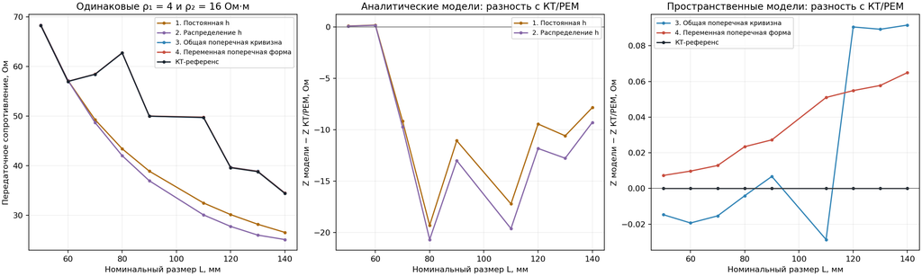

| Модель | RMSE к КТ/PEM, Ом | Макс. \|разность\|, Ом |
| --- | --- | --- |
| 2. Распределение h | 12.76728 | 20.69625 |
| 1. Постоянная h | 11.24819 | 19.30498 |
| КТ-референс | 0.00000 | 0.00000 |
| 3. Общая поперечная кривизна | 0.05403 | 0.09160 |
| 4. Переменная поперечная форма | 0.04051 | 0.06495 |

**Отдельный контроль CEM:** одинаковые конечные площадки и контактное сопротивление во всех трёх пространственных моделях.

| Модель | RMSE к КТ/CEM, Ом | Макс. \|разность\|, Ом |
| --- | --- | --- |
| 3. Общая поперечная кривизна | 0.06185 | 0.12632 |
| 4. Переменная поперечная форма | 0.04135 | 0.07139 |

**Рисунок 11.4а. Прямое сравнение пяти операторов для одного синтетического состояния.** Слева представлены импедансы для девяти размеров $L$, мм; в центре — знаковые разности аналитических моделей относительно КТ/PEM; справа — соответствующие разности пространственных моделей. По горизонтальной оси отложен размер сборки $L$, мм, по вертикальной — импеданс или разность импедансов, Ом. Близость к нулю означает лучшее воспроизведение выбранного референса в данном состоянии; раздельные масштабы панелей нельзя сравнивать по высоте линий без чтения их осей. Нулевая линия КТ получена вычитанием результата из самого себя и не является нулевой физической погрешностью FEM.

**Результат для этого состояния.** При заранее заданных и не подогнанных сопротивлениях $\rho_1=4$ и $\rho_2=16$ Ом·м RMSE относительно КТ/PEM составляет 11,248 Ом для М1, 12,767 Ом для М2, 0,0540 Ом для М3 и 0,0405 Ом для М4. Переменная пространственная форма даёт наименьший RMSE среди четырёх кандидатов по девяти размерам, но не минимальную ошибку для каждого размера. Добавление профиля глубины в М2 ухудшило прямой прогноз относительно М1: дополнительная геометрическая информация внутри эвристического усреднения не гарантирует более точного электрического поля.

Этот опыт оценивает только прямой оператор при известных сопротивлениях и не устанавливает точность обратного восстановления неизвестных $\rho_1,\rho_2$. Для этого нужны синтетические наблюдения с известными параметрами и отдельная инверсия. В таблице и на рисунке следует различать невязки относительно PEM и CEM: различие контактного представления является самостоятельной составляющей сравнения. Рассчитанные включения в полупространстве входят в общий результат 20.16; подробности решателей — в 20.17.

## 20. Локализация боковой сборки по сохранённому многоразмерному FEM-перебору

### 20.1. Исследовательский вопрос и статус результата

Рассматриваются два связанных вопроса: какое положение боковой сборки лучше воспроизводит экспериментальную зависимость импеданса от её размера и насколько точно ту же FEM-кривую можно заменить классической двуслойной моделью с одной общей толщиной. Второй вопрос относится к сокращению анатомической информации в разрабатываемой методике. Оценка фактической установки и выбор упрощения требуют разных критериев; минимум одного из них не гарантирует минимума другого.

**Статус: результат математической модели, не прошедший независимую физическую валидацию.** Анализ использует сохранённую часть остановленного перебора. Он подтверждает вычислительные свойства этого набора, но не устанавливает истинное место наклейки, универсальные сопротивления тканей или точность показателей функции сердца. Выбор информативной пары размеров является отдельной задачей; здесь все девять размеров используются совместно.

Изложение соответствует снимку результатов на 10 сентября 2026 года. Новые решения полевой FEM-задачи при подготовке этого раздела не вычислялись. Подробная интерактивная карта центров и поворотов дополняет рисунки, а трёхмерный вид выбранной сборки позволяет переключать все девять размеров.

### 20.2. Входные данные и их происхождение

Расчёт относится к добровольцу Ник из эксперимента 2, выполненного на реокардиомониторе МГТУ. Используются агрегированные уровни импеданса на задержке дыхания после вдоха и индивидуальная геометрия КТ на вдохе. Эти уровни получены обработкой записей, а геометрия — ручной сегментацией КТ в Inobitec. Состояния дыхания сопоставлены в рамках рабочего допущения: их совпадение по объёму лёгких не измерено. Границы дыхательных проб являются экспертной реконструкцией, поскольку прибор не записывал временные метки команд.

В размерный ряд входят девять самостоятельных, не дублирующих друг друга записей данного добровольца. Размер 100 мм исключён как поздняя копия записи 90 мм; сама запись 90 мм сохранена. Это субъектное решение не переносится на других добровольцев. Значения в таблице приведены до трёх знаков; ранжирование выполнено по полной сохранённой точности.

| L, мм | Эксперимент, Ом | FEM в выбранной позе, Ом | FEM − эксперимент, Ом |
| --- | --- | --- | --- |
| 50 | 85,689 | 83,364 | -2,325 |
| 60 | 101,102 | 100,443 | -0,659 |
| 70 | 88,678 | 88,773 | 0,095 |
| 80 | 83,943 | 84,178 | 0,235 |
| 90 | 74,580 | 70,718 | -3,862 |
| 110 | 65,581 | 69,638 | 4,057 |
| 120 | 62,821 | 60,864 | -1,957 |
| 130 | 60,923 | 57,937 | -2,986 |
| 140 | 50,103 | 55,074 | 4,971 |

*Таблица 20.1. Экспериментальный размерный ряд, FEM-прогноз в выбранной позе и остатки с учётом знака. Размер L — номинальное расстояние между внешними токовыми электродами.*

| Вход | Способ получения | Научное ограничение |
| --- | --- | --- |
| Экспериментальные импедансы | Агрегаты записанного сигнала; исходная таблица содержит ссылки на записи и признак независимости | Повторное использование этих значений для выбора позы не является независимой валидацией |
| Внешняя поверхность и тканевые области | КТ на вдохе, ручная сегментация и последующая сеточная обработка | Неопределённость сегментации и соответствие состоянию электрического измерения количественно не установлены |
| Положение сборки | Расчётная параметризация центра и поворота, проекция на поверхность | Фактические координаты каждой экспериментальной установки независимо не измерены |
| Удельные сопротивления мягких тканей и лёгкого | Перенесены из предыдущей совместной подгонки к этому размерному ряду | Это оценки модели, а не непосредственно измеренные свойства тканей |
| Остальные материалы и контакты | Фиксированная конфигурация четырёхматериальной FEM-модели | Их неопределённость в текущем переборе не варьируется |

Первичные агрегаты доступны в таблице уровней на задержках дыхания. Их наличие не заменяет принятия всех этапов файлового контроля, дыхательной разметки и оценки интервалов в основной последовательности ноутбуков 10.01, 11.01 и 12.01.

### 20.3. Физическая постановка и допущения

Сохранённые полевые решения рассчитаны для четырёх областей: мягкие ткани, лёгкое, сердце и кость. Контакты описаны полной электродной моделью (CEM) с конечными непересекающимися площадками. Расчётная частота составляет 50 кГц; используемый отклик сопоставляется с вещественными уровнями импеданса. Текущий анализ не является отдельным двухтканным опытом раздела 11.3.1 или ноутбука 20.13.

Во всём сохранённом переборе фиксированы удельные сопротивления мягких тканей ρ₁ = 5,5521664546649 Ом·м и лёгкого ρ₂ = 30,7069468090815 Ом·м. Геометрия и параметры сердца и кости также фиксированы. Заданная площадь контакта равна 70,686 мм²: это площадь круга диаметром 10 мм, умноженная на коэффициент 0,9. Фактическая площадь складывается из выбранных граничных треугольников и может отличаться от заданной. Удельный контактный импеданс принят равным приблизительно 1,592·10⁻⁴ Ом·м². Эти контактные параметры относятся к модели и не являются результатом измерения контакта в каждой записи.

| Допущение | Зачем оно необходимо | Проверка и следствие |
| --- | --- | --- |
| Последовательные записи разных размеров представляют сопоставимое физиологическое состояние | Чтобы образовать единый размерный вектор | Принято автором; межзаписная изменчивость остаётся источником погрешности |
| Все размеры описываются одной позой центра и поворота | Чтобы решать общую задачу локализации | Ошибки переклейки отдельных сборок не идентифицированы |
| Геометрия и параметры тканей постоянны внутри перебора | Чтобы сопоставлять влияние положения | Минимум условен относительно выбранных анатомии, контактов и сопротивлений |
| Равные веса девяти размеров | Чтобы использовать однозначный критерий без необоснованного задания ковариации ошибок | Это вычислительное решение; модель распределения совокупной ошибки не установлена |
| Маска исключает заданные поверхности рук и искусственных срезов | Чтобы ограничить область предполагаемого бокового монтажа | Это геометрическое правило конкретной модели, а не клиническая оценка возможности установки |
| Плоские слои и точечные электроды в аналитическом приближении | Чтобы проверить возможность замены индивидуального полевого расчёта одной толщиной | Ошибка приближения одновременно включает различия анатомии, материалов и контактов |

Источники расхождений рассматриваются раздельно: вариабельность дыхания и сердечных циклов; изменение состояния между записями; фиксированный порядок съёмки; возможные аппаратные изменения и межканальное влияние; неопределённость калибровки; контакт; ручная переклейка; расстояния и ориентация; сегментация; конечноэлементная дискретизация; несоответствие плоских слоёв реальной анатомии. Их независимость, гауссовость и суммарная дисперсия не установлены. Произвольный масштаб или сдвиг экспериментального импеданса в этой подгонке не вводится.

### 20.4. Критерий локализации и полнота перебора

Поза задаётся двумя координатами на исходной параметрической плоскости и поворотом. После проекции на поверхность шаг параметра не обязательно равен физическому перемещению центра. Оценивается среднеквадратическое расхождение по всем размерам:

$$ E_{\mathrm{exp}}(\boldsymbol\theta)= \sqrt{\frac{1}{N}\sum_{i=1}^{N} \left[z_i(\boldsymbol\theta)-y_i\right]^2}, \qquad \boldsymbol\theta=(u,v,\varphi),\quad N=9, $$

где $E_{\mathrm{exp}}$ — ошибка RMSE, Ом; $z_i$ — сохранённый FEM-импеданс для размера $L_i$, Ом; $y_i$ — соответствующий экспериментальный уровень, Ом; $i$ — номер размера; $N$ — число размеров; $u,v$ — координаты параметризации, мм; $\varphi$ — угол поворота, градусы. Это критерий подгонки, а не оценка вероятности или доверия к позе.

Полная заданная сетка содержит 38 801 центр: $u$ от −80 до 80 мм и $v$ от −120 до 120 мм с шагом 1 мм; в каждом центре задан 41 поворот от −20 до 20° с шагом 1°. Всего предусмотрено 1 590 841 поза. Обработаны 300 блоков, охватывающих 19 200 центров. Состояния всего множества распределены следующим образом:

| Состояние позы | Число | Значение для анализа |
| --- | --- | --- |
| Допустима и рассчитана | 475 090 | Есть девять FEM-импедансов; участвует в ранжировании |
| Отклонена геометрическим контролем | 95 192 | Контакт не удовлетворяет принятым численным условиям |
| Исключена маской поверхности | 216 918 | Не входит в принятую область монтажа |
| Ещё не проверена | 803 641 | Нельзя судить ни о допустимости, ни об ошибке |

Контроль контактов включает расстояние до поверхности не более 5 мм, смещение центра площади не более 4,743 мм, отношение фактической площади к заданной от 0,95 до 1,5, а также условия связности и непересечения площадок. Отказ такого контроля не означает установленную физическую невозможность наклейки. Он также не является большим значением RMSE: для отвергнутой позы пригодный отклик отсутствует.

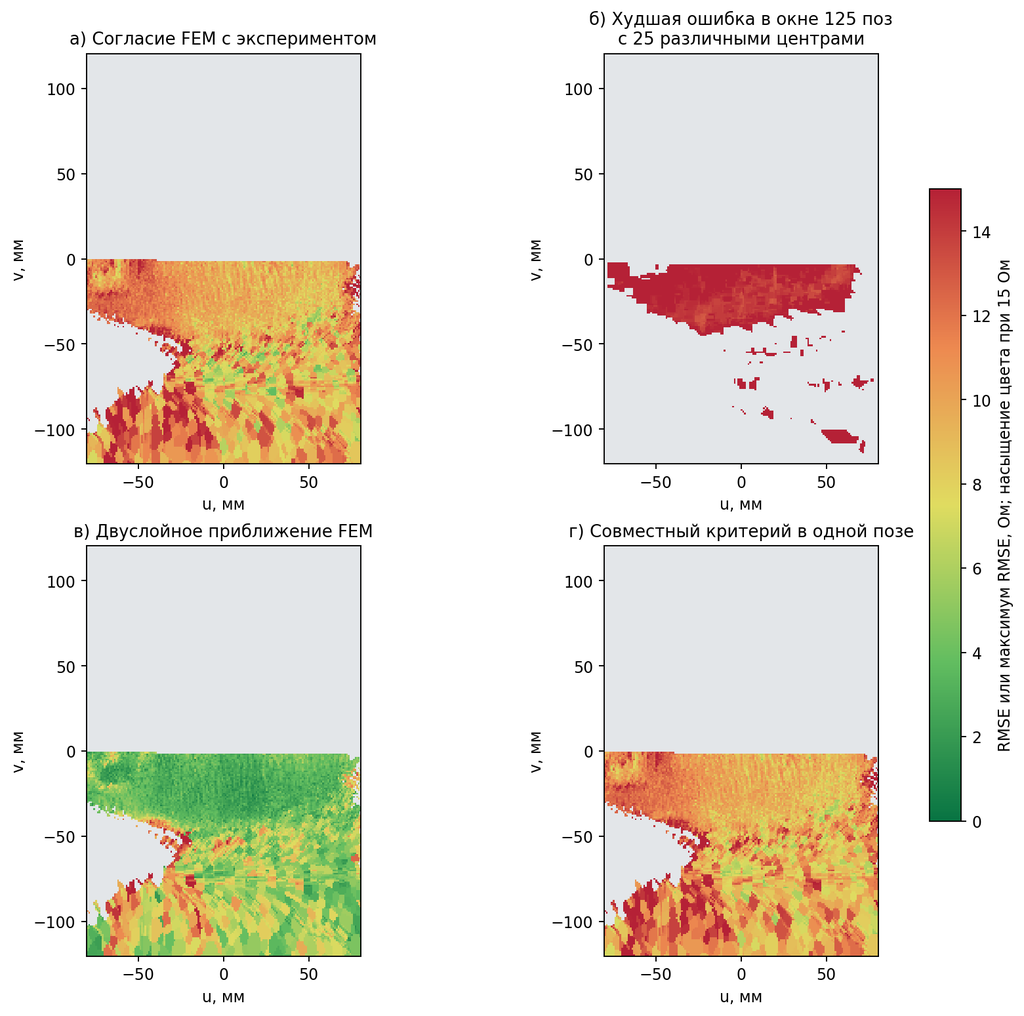

*Рисунок 20.1. Карты критериев на сохранённой параметрической сетке локализации. По координатам $u$ и $v$ показаны: а — минимум ошибки FEM относительно эксперимента по углу в каждом центре; б — минимум худшей ошибки в полностью рассчитанном окне 5×5×5; в — минимум ошибки двуслойного приближения для FEM-кривой; г — минимум большей из двух ошибок в одной и той же позе. Единицы $u$ и $v$ — мм, ошибки — Ом; для каждой панели цвет выбирает наилучший доступный угол. Чем меньше ошибка, тем зеленее цвет, а при 15 Ом шкала насыщается. Серый цвет означает отсутствие пригодного значения из-за геометрического отказа, маски или отсутствия расчёта и не равен нулевой ошибке. Карта описывает обработанную часть перебора и не доказывает минимум непрерывной позы. Следующая проверка — локальное дискретное окно и контроль исключённых размеров.*

### 20.5. Выбранная поза и координаты электродов

Минимальная ошибка к эксперименту среди рассчитанных допустимых поз равна **2,881827921 Ом** при $u=13$ мм, $v=-55$ мм и $\varphi=14°$. В сопроводительных таблицах эта поза обозначена C01. Её проецируемый центр в исходной системе координат КТ/FEM равен приблизительно **(−187,500; 31,051; −138,051) мм**. Это координаты численного кандидата; без пространственной регистрации они не задают точку на теле при повторном исследовании.

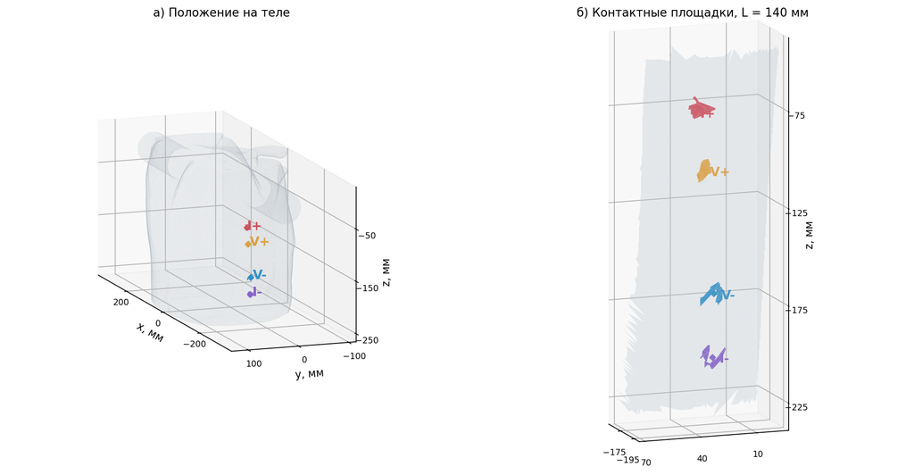

*Рисунок 20.2. Пространственное положение электродных площадок в кандидате C01. На панели а показана вся индивидуальная поверхность тела и все сборки, на панели б — локальный фрагмент для $L=140$ мм. Цветом обозначены фактические треугольные площадки CEM: $I+$ и $I-$ — токовые, $V+$ и $V-$ — измерительные контакты; ромбы показывают их центры площади. Координаты $x$, $y$, $z$ заданы в мм исходной системы КТ/FEM. Изображены контакты численной модели, а не фотографически восстановленная наклейка; поэтому фигура подтверждает сохранённую геометрию расчёта, но не фактическую установку на теле. Следующая таблица содержит численные координаты и площади; значения округлены для чтения.*

| Электрод | x центра площади, мм | y, мм | z, мм | Площадь, мм² |
| --- | --- | --- | --- | --- |
| I+ | -198,780 | 38,952 | -70,929 | 83,00 |
| V+ | -193,848 | 35,113 | -103,976 | 72,85 |
| V- | -178,607 | 24,531 | -171,100 | 89,11 |
| I- | -169,681 | 22,033 | -205,772 | 72,76 |

*Таблица 20.2. Координаты центров площади и фактические площади четырёх контактов при L = 140 мм. Округление в таблице служит для чтения и не задаёт точность физической локализации.*

Для 15 показательных кандидатов сохранены 540 электродных записей: четыре контакта для девяти размеров. Проектируемый центр электрода и центр площади CEM-контакта записаны отдельно; максимальная разность в этом наборе достигает 4,439 мм. Их отождествление создало бы дополнительную геометрическую ошибку. Доступны координаты всех размеров выбранной позы и координаты всех кандидатов.

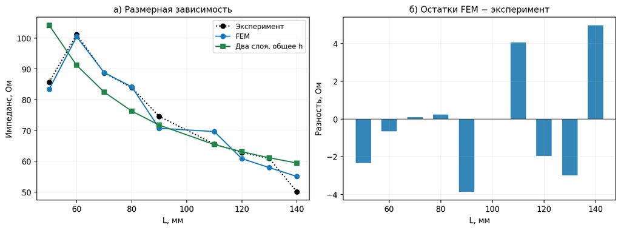

*Рисунок 20.3. Сопоставление размерных зависимостей в выбранной позе. На панели а по оси $L$ отложен номинальный размер сборки, мм, по оси $Z$ — импеданс, Ом; показаны эксперимент, FEM и двуслойная модель с одной общей подобранной толщиной. На панели б приведены остатки $Z_{\rm FEM}-Z_{\rm эксп}$ для каждого размера, поэтому знак показывает направление расхождения. Линии соединяют дискретные наблюдения и не задают непрерывную зависимость. Доверительные интервалы не строились: распределение ошибок и независимость последовательных записей не установлены.*

### 20.6. Что доказывает проверка минимума

Повторное вычисление критерия из всех 475 090 сохранённых FEM-векторов установило единственный минимум среди этих допустимых поз; равенств в пределах 10⁻¹⁰ Ом не найдено. Следующая поза имеет тот же центр и угол 13°; её RMSE равна 2,931431723 Ом, то есть выше на 0,049603802 Ом.

Локальное окно с отклонениями не более одного шага по каждому параметру содержит 27 поз, включая выбранную: 15 допустимых, 12 отвергнутых геометрическим контролем и ни одной непроверенной. Для всех остальных допустимых поз этого окна выполняется строгое неравенство:

$$ E_{\mathrm{exp}}(\boldsymbol\theta_*)< E_{\mathrm{exp}}(\boldsymbol\theta) \quad\text{для всех}\quad \boldsymbol\theta\in\mathcal S\cap\mathcal N_1(\boldsymbol\theta_*), \quad \boldsymbol\theta\ne\boldsymbol\theta_*, $$

где $\boldsymbol\theta_*$ — выбранная поза; $\mathcal S$ — множество рассчитанных поз, прошедших геометрический контроль; $\mathcal N_1$ — окно ±1 мм по параметрам $u,v$ и ±1° по углу; $E_{\mathrm{exp}}$ — определённая выше ошибка, Ом. Полнота проверенного локального окна позволяет говорить о строгом минимуме на его **дискретном допустимом множестве**.

| Изменение параметра | RMSE, Ом |
| --- | --- |
| v − 1 | 10,298911 |
| u − 1 | Отказ геометрического контроля |
| φ − 1 | 2,931432 |
| φ + 1 | 5,844396 |
| u + 1 | 10,255963 |
| v + 1 | Отказ геометрического контроля |

*Таблица 20.3. Шесть осевых соседей при изменении только одного параметра на один шаг. Остальные параметры равны значениям выбранной позы.*

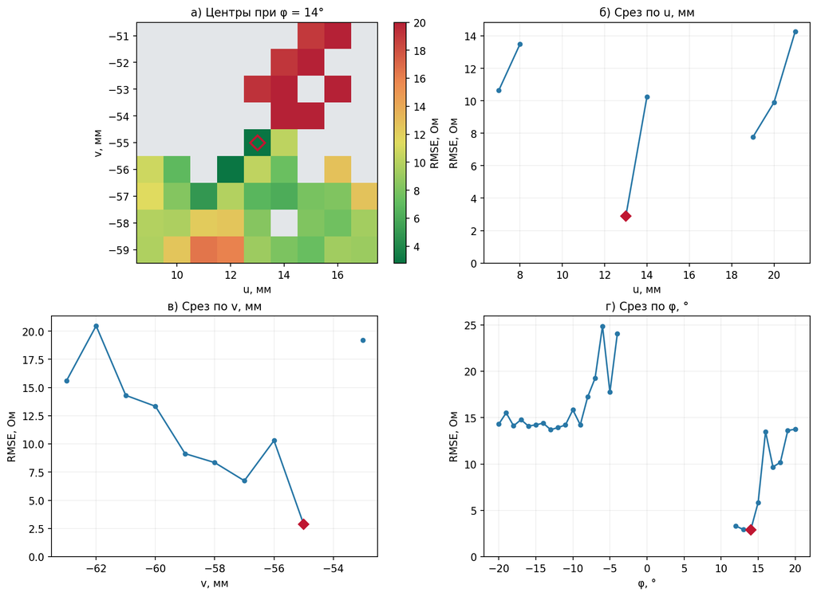

*Рисунок 20.4. Локальная структура дискретной ошибки вокруг C01. На панели а показана RMSE в плоскости $(u,v)$ при фиксированном $\varphi=14^\circ$; на панелях б–г приведены срезы при изменении одного параметра. Координаты $u$ и $v$ выражены в мм, угол — в градусах, ошибка — в Ом. Ромб отмечает C01, серые ячейки и разрывы линий — позы без пригодного FEM-значения. Рисунок подтверждает локальный минимум на узлах сохранённой сетки, но не форму функции между ними и не непрерывную точность координат.*

Это проверка перебором с точностью сохранённых полевых решений. Она не доказывает минимум при непрерывном перемещении: шаги меньше 1 мм по параметрам и 1° по углу не исследованы. Она также не доказывает минимум на всей незавершённой сетке или при совместном изменении сопротивлений. Ошибка пространственной FEM-дискретизации в разность 0,0496 Ом этой проверкой не включена.

### 20.7. Чувствительность выбора к данным

Малая разность ошибок первой и второй поз требует проверки устойчивости ранжирования. Для фиксированной библиотеки FEM-векторов рассчитано наименьшее среднеквадратическое изменение экспериментального вектора, при котором выбранная поза может сравняться по ошибке с конкурентом:

$$ r_* = \min_{q\ne p} \frac{\|\mathbf z_q-\mathbf y\|_2^2- \|\mathbf z_p-\mathbf y\|_2^2} {2\sqrt N\,\|\mathbf z_q-\mathbf z_p\|_2} =0{,}077441953\ \text{Ом}, $$

где $p$ — индекс выбранной позы; $q$ — индекс другой рассчитанной допустимой позы с отличным FEM-вектором; $\mathbf z_p,\mathbf z_q$ — векторы девяти FEM-импедансов, Ом; $\mathbf y$ — экспериментальный вектор, Ом; $N=9$; $\|\cdot\|_2$ — евклидова норма; $r_*$ — порог по RMS возмущения данных, то есть по $\|\delta\mathbf y\|_2/\sqrt N$, Ом; $\delta\mathbf y$ — изменение экспериментального вектора, Ом. Формула следует из расстояния до гиперплоскости равных квадратов ошибок двух векторов.

При возмущении с RMS меньше этого порога выбранная поза остаётся единственным минимумом данной библиотеки. На пороге существует направление возмущения, создающее равенство; конкурентом является тот же центр с углом 13°. Проверка возмущения вдоль разности FEM-векторов подтвердила смену порядка после увеличения порогового возмущения на 1%. Порог **не является измеренным шумом или доверительной границей**: библиотека FEM здесь условно считается точной, а экспериментальная модель ошибки не задана.

Дополнительно локализация повторена девять раз по восьми размерам с прогнозом исключённого девятого. В каждом повторе сравнивались все сохранённые допустимые позы. Исходная поза выбрана только в трёх из девяти случаев. При исключении 50 мм центр смещается приблизительно на 33 мм, а ошибка прогноза этого размера превышает 40 Ом.

| Исключённый L, мм | u; v, мм | φ, ° | Смещение центра, мм | Ошибка исключённого размера, Ом |
| --- | --- | --- | --- | --- |
| 50 | -13; -85 | 1 | 33,00 | 40,34 |
| 60 | 13; -55 | 14 | 0,00 | -0,66 |
| 70 | 11; -56 | 17 | 0,87 | 18,92 |
| 80 | 9; -55 | 17 | 2,98 | 12,58 |
| 90 | 26; -78 | -7 | 22,75 | -9,31 |
| 110 | 13; -55 | 12 | 0,00 | 6,51 |
| 120 | 13; -55 | 14 | 0,00 | -1,96 |
| 130 | 26; -71 | 9 | 19,50 | -5,94 |
| 140 | 13; -55 | 14 | 0,00 | 4,97 |

*Таблица 20.4. Локализация с поочерёдным исключением размера. Смещение — евклидово расстояние между проецируемыми центрами в координатах КТ; нулевое смещение не исключает изменения угла. Ошибка с учётом знака относится только к исключённому размеру.*

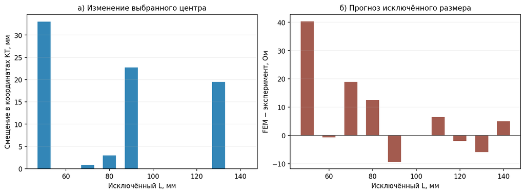

*Рисунок 20.5. Устойчивость локализации при поочерёдном исключении размера. Для каждого исключённого $L$, мм, показаны смещение выбранного проецируемого центра, мм, и ошибка прогноза исключённого импеданса с учётом знака, Ом. Нулевое смещение не исключает изменения угла; девять повторов используют один и тот же набор последовательных записей и не являются независимыми экспериментами. Рисунок проверяет зависимость выбора от состава размерного ряда, но не даёт статистической оценки точности установки.*

### 20.8. Роль ранее подобранных удельных сопротивлений

**В сохранённой части перебора сопротивления не варьировались.** Для всех центров и поворотов использовалась одна пара ρ₁, ρ₂, приведённая в разделе 20.3. Последующий подбор общей толщины также сохранял эту пару.

Ранее выполнялась совместная подгонка пяти параметров: двух сопротивлений, двух координат центра и угла. Сохранённая история содержит 100 оценок и 24 различные пары сопротивлений; поиск завершён по лимиту вычислений. В этой истории ρ₁ изменялось приблизительно от 4,615 до 6,115 Ом·м, а ρ₂ — от 21,707 до 32 Ом·м. Это диапазоны фактически проверенных значений, а не доверительные интервалы.

Предыдущий критерий включал функцию Хьюбера от остатков, дополнительный штраф за форму размерной зависимости и априорные штрафы для глубины и сопротивления лёгкого. Он отличается от текущей равновзвешенной RMSE. Его лучший сохранённый кандидат имел RMSE около 7,288 Ом и другую позу. Перенос сопротивлений из этой подгонки делает нынешний минимум условным; ни завершённость совместной оптимизации, ни независимое восстановление сопротивлений этим не доказаны. Происхождение зафиксировано в сводке прежнего поиска.

### 20.9. Двуслойное приближение с одной общей толщиной

Для каждой FEM-кривой подбирается только одна эффективная толщина. Верхний слой и нижнее полупространство имеют фиксированные сопротивления ρ₁ и ρ₂. Четыре точечных электрода расположены на одной прямой: I+, V+, V−, I− имеют координаты −L/2, −L/4, L/4, L/2 соответственно. Положительный передаточный импеданс задаётся разностью потенциалов V+ и V−, делённой на ток I+.

$$ \begin{aligned} Z_{\mathrm{2L}}(h,L)&=\frac{\rho_1}{\pi} \left[D_L(0)+2\sum_{n=1}^{\infty}q^nD_L(2nh)\right],\\ D_L(t)&=\frac{1}{\sqrt{(L/4)^2+t^2}} -\frac{1}{\sqrt{(3L/4)^2+t^2}},\\ q&=\frac{\rho_2-\rho_1}{\rho_2+\rho_1}, \end{aligned} $$

где $Z_{\mathrm{2L}}$ — двуслойный передаточный импеданс, Ом; $h$ — толщина верхнего слоя, м; $L$ — расстояние между внешними токовыми электродами, м; $t$ — вспомогательное расстояние, м; $D_L$ — геометрическая функция, м⁻¹; $\rho_1,\rho_2$ — удельные сопротивления, Ом·м; $q$ — безразмерный коэффициент отражения; $n$ — положительный целочисленный номер члена ряда. Перед вычислением длины из таблиц переводятся из миллиметров в метры умножением на 10⁻³.

Для каждой позы минимизируется ошибка по всем девяти размерам:

$$ \begin{aligned} F(h;\boldsymbol\theta)&=\sqrt{\frac1N\sum_{i=1}^N \left[Z_{\mathrm{2L}}(h,L_i)-z_i(\boldsymbol\theta)\right]^2},\\ E_{\mathrm{2L}}(\boldsymbol\theta)&=\min_{h\ge0}F(h;\boldsymbol\theta),\\ h_{\mathrm{eff}}(\boldsymbol\theta)&\in\operatorname*{arg\,min}_{h\ge0}F(h;\boldsymbol\theta), \end{aligned} $$

где $F$ — RMSE двуслойного приближения при заданных толщине и позе, Ом; $E_{\mathrm{2L}}$ — её минимальное значение, Ом; $h_{\mathrm{eff}}$ — выбранная общая эффективная толщина, м; $\boldsymbol\theta$ — фиксированная поза; $L_i$ — размер сборки, м; $z_i$ — FEM-импеданс, Ом; $N=9$; $Z_{\mathrm{2L}}$ — определённая выше аналитическая функция. В расчёте отдельно проверен предел при $h\to\infty$; он включён в сравнение с конечными кандидатами. Отдельные толщины для каждого размера, дополнительный масштаб и сдвиг отсутствуют.

Адаптивная аппроксимация ряда охватывает неотрицательную полуось и её предельный отклик. В используемом алгоритме оценка ошибки глобального минимума RMSE не превышает 0,001 Ом; итоговые импедансы пересчитаны исходным аналитическим рядом. Все 475 090 найденных минимумов имеют конечную толщину. Медиана $h_{\mathrm{eff}}$ составляет 25,243 мм, медиана ошибки к FEM — 8,669 Ом. Это медианы по параметрическим позам данного снимка, а не популяционные характеристики тканей.

При исключении по одному размеру дополнительно выполнены 4 275 810 подгонок толщины по восьми размерам с прогнозом девятого; медиана RMSE таких прогнозов равна 9,466 Ом. В отличие от раздела 20.7, здесь **поза фиксирована**, а повторно выбирается только толщина. Проверка оценивает воспроизведение размерной зависимости, но не анатомическую идентифицируемость толщины.

### 20.10. Совместимость двух критериев и отрицательный результат

| Критерий выбора | u; v, мм | φ, ° | FEM ↔ эксперимент, Ом | Два слоя ↔ FEM, Ом | h, мм |
| --- | --- | --- | --- | --- | --- |
| Минимум ошибки к эксперименту | 13; -55 | 14 | 2,882 | 8,649 | 24,704 |
| Минимум ошибки двуслойного приближения | 17; -26 | 13 | 10,073 | 0,530 | 29,824 |
| Минимум большей из двух ошибок | 13; -77 | -8 | 4,664 | 4,535 | 24,877 |

*Таблица 20.5. Три разных решения: минимум ошибки к эксперименту, минимум ошибки двуслойного приближения и минимум большей из этих двух ошибок. Параметры сопротивлений одинаковы во всех строках.*

Совместный критерий в каждой позе определяется как максимум двух ошибок:

$$ E_{\mathrm{joint}}(\boldsymbol\theta)= \max\left\{E_{\mathrm{exp}}(\boldsymbol\theta), E_{\mathrm{2L}}(\boldsymbol\theta)\right\}, $$

где $E_{\mathrm{joint}}$ — совместная ошибка, Ом; $E_{\mathrm{exp}}$ — ошибка FEM к эксперименту, Ом; $E_{\mathrm{2L}}$ — ошибка двуслойного приближения той же FEM-кривой, Ом; $\boldsymbol\theta$ — одна и та же поза. Минимумы по углу для двух ошибок по отдельности не объединяются в фиктивную общую позу.

Ошибка к эксперименту ниже 5 Ом получена для 196 поз в 132 параметрических центрах, ниже 3 Ом — для трёх поз в двух центрах. Обе ошибки одновременно ниже 5 Ом имеют только четыре позы в трёх центрах: $(u,v,\varphi)=(13,-77,-8)$, $(26,-80,9)$, $(26,-80,10)$ и $(57,-47,12)$; координаты выражены в миллиметрах, углы — в градусах. Эти пороги являются исследовательскими сценариями, а не доверительными областями или клиническими критериями пригодности.

При выбранных сопротивлениях ρ₂ > ρ₁ все дополнительные члены ряда неотрицательны. Поэтому существует нижняя граница:

$$ Z_{\mathrm{2L}}(h,L)\ge\frac{8\rho_1}{3\pi L}, $$

где $Z_{\mathrm{2L}}$ — импеданс, Ом; $h\ge0$ — толщина, м; $L$ — размер сборки, м; $\rho_1$ — сопротивление верхнего слоя, Ом·м. При L = 50 мм граница равна 94,257 Ом, тогда как FEM в лучшей экспериментальной позе даёт 83,364 Ом. Следовательно, никакая толщина при этой паре сопротивлений не воспроизведёт данный компонент FEM-вектора.

Даже непосредственный подбор общей толщины к экспериментальному вектору при тех же сопротивлениях даёт минимальную RMSE 8,378 Ом. Это отрицательный результат для выбранного упрощения и фиксированных параметров. Он не доказывает неисправность прибора и не исключает другие сопротивления или модели контакта и анатомии.

### 20.11. Эффективная толщина и геометрия КТ

В центрах с допустимыми позами выполнена трассировка луча по внутренней нормали к внешней поверхности. Первый вход в лёгкое найден для 15 977 центров; в 978 центрах пересечения не найдено в диапазоне 600 мм. Отсутствие пересечения в этом диапазоне не заменяется нулевой толщиной. Замкнутость поверхностей лёгкого и кости проверена; в одном костном луче пересечения не образовали надёжных пар, поэтому соответствующая длина кости не выдана.

Глубина первого входа доступна для 459 231 параметрической позы. При её подстановке вместо подбора толщины медиана RMSE к FEM составляет 16,652 Ом. На том же наборе подбор общей толщины даёт медиану 8,662 Ом. Медиана разности «эффективная толщина минус глубина по нормали» равна −29,070 мм.

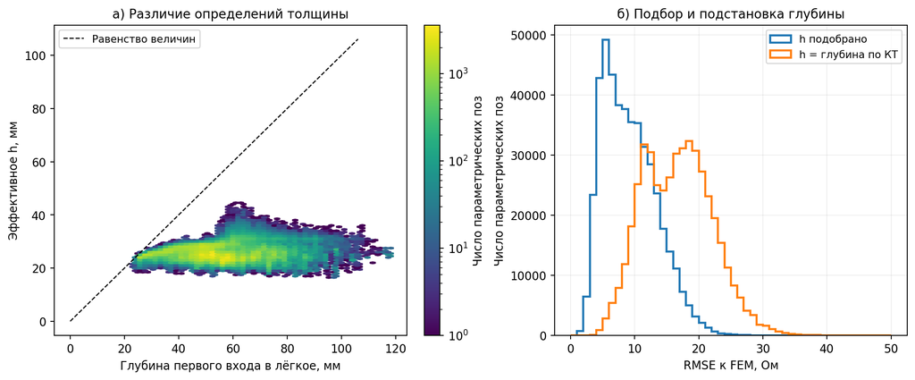

*Рисунок 20.6. Сравнение эффективной и геометрической толщины. На панели а по обеим осям отложена толщина в мм: $h_{\rm eff}$, найденная по электрическому критерию, и глубина первого входа в лёгкое по нормали КТ; штриховая линия обозначает равенство, цвет — число поз в ячейке. На панели б показаны распределения RMSE к FEM при подборе общей толщины и при прямой подстановке глубины КТ; ошибка выражена в омах, диапазон ограничен 50 Ом. Частоты относятся к элементам перебора, а не к независимым наблюдениям. Различие распределений показывает, что электрически эффективная толщина не может автоматически считаться анатомической; следующая задача — оценить её устойчивость и неопределённость отдельно от подгонки.*

Геометрический путь до лёгкого может включать мягкие ткани и кость. Он не равен отдельно измеренной толщине мягких тканей. Эффективная толщина компенсирует совокупное расхождение аналитической модели и FEM; её нельзя автоматически объявлять анатомической. Использовавшееся ранее расстояние до ближайшей вершины поверхности также имеет иное определение и не заменяет нормальную глубину.

Для кандидатов сохранены профили глубины, длина первого лёгочного интервала, длины костных участков перед лёгким и квадратичная одномерная характеристика изгиба лёгочной границы вдоль оси сборки. Последняя описывает выбранное направление и не является главной кривизной трёхмерной поверхности. Влияние кривизны, конечности лёгкого, костей, внешнего контура и конечного контакта пока не разделено причинным вычислительным экспериментом.

### 20.12. Пространственная устойчивость и вырождение параметризации

Дополнительный сценарий использует окно ±2 шага по обеим координатам и углу: 125 поз. Требуется, чтобы все они были рассчитаны и допустимы. Ни для одной области этого сценария ошибка к эксперименту во всех позах не остаётся ниже 10 Ом. У лучшей экспериментальной позы допустимы 69 из 125 поз, а ошибка среди них достигает 23,551 Ом; 56 поз отвергнуты геометрическим контролем. У компромиссной позы допустимы 79 из 125, а максимальная ошибка равна 24,153 Ом.

Проверка проекций показала, что 16 955 параметрическим центрам с допустимыми позами соответствуют только 10 908 различных координатных точек при округлении до 10⁻⁶ мм. В 92 центрах все 25 соседних проецируемых центров совпадают. Поэтому формально лучшее значение худшей ошибки 10,315 Ом не проверяет устойчивость к перемещению: центр в таком окне вообще не меняется.

После дополнительного требования 25 различных проекций и ненулевого пространственного разброса по двум направлениям минимум худшей ошибки составляет 12,679 Ом. Для этого сценария второй сингулярный показатель пространственного разброса должен превышать 0,001 мм; это численный порог отбраковки вырожденного окна, а не измеренная погрешность установки. У компромиссной позы изменение на два шага по обеим координатам может сместить центр на 6,349 мм и изменить нормаль до 18,153°.

Следовательно, рассмотренное окно — сценарий параметрической сетки. Оно не описывает равномерную ошибку наклейки ±2 мм на теле. Для такой интерпретации требуется отдельная геометрическая постановка в физических касательных координатах и проверка дискретизации контактов.

### 20.13. Выполненные проверки и границы доказательства

| Утверждение | Основание | Статус и предел вывода |
| --- | --- | --- |
| Выбранная поза имеет минимальную RMSE в сохранённом допустимом наборе | Повторное вычисление критерия по всем 475 090 векторам; проверка соседей | Подтверждённый вычислительный факт для дискретного множества при фиксированных сопротивлениях |
| Изображённые контакты соответствуют сохранённому CEM | Повторное суммирование площадей и центров треугольников | Максимальные расхождения около 7,1·10⁻¹⁴ мм² и 5,4·10⁻¹³ мм; подтверждает экспорт геометрии, а не реальную наклейку |
| Подбор общей толщины выполнен согласованно с аналитическим рядом | Контроль граничных случаев, оценка аппроксимации и независимые повторные минимизации | На 50 позах из сохранённого расчётного набора в 200 повторных поисках максимальное расхождение RMSE около 4,1·10⁻⁶ Ом; это проверка численного метода |
| Часть поз одновременно согласуется с экспериментом и двуслойным приближением при пороге 5 Ом | Совместный критерий в одной позе | Четыре кандидата; порог сценарный, устойчивость области не установлена |
| Фактическая установка восстановлена однозначно | Независимого пространственного референса нет | Нерешённый вопрос; чувствительность ранжирования и исключение размеров ограничивают такой вывод |
| Эффективная толщина заменяет измерение анатомии | Сравнение с глубиной по КТ показывает различие величин | Не подтверждено; переход к сокращённому протоколу требует отдельной проверки |

Самоконтроль кода, согласие двух реализаций и сохранность файлов не заменяют сеточной сходимости FEM, независимой метрологической проверки и повторного эксперимента. Не установлены точность непрерывной локализации, неопределённость тканевых параметров, влияние сегментации и контакта, перенос на другое дыхательное состояние или другую сессию. Значения сердца, лёгкого и мягких тканей не интерпретируются как независимо восстановленные физиологические параметры только на основании близости базовых импедансов.

**Итог данного этапа.** Получен прослеживаемый кандидат установки и доказан его дискретный минимум в сохранённой части перебора. Одновременно обнаружены малая устойчивость ранжирования к изменению данных, зависимость локализации от состава размерного ряда и различие эффективной и геометрической толщин. Поэтому результат пригоден как исходная гипотеза для следующей проверки, но пока не обосновывает исключение индивидуальной КТ или сокращение измерений до двух сборок.

### 20.14. Воспроизводимость и дополнительные материалы

В ноутбуке сохранены исходные вычислительные ячейки и их численные выходы. Настоящий раздел сформирован из существующих массивов FEM, результатов подбора толщины, геометрических таблиц и проверки минимума. Контрольные суммы связывают текст, рисунки и входные файлы; подготовка рисунков не запускает полевой расчёт.

| Материал | Назначение |
| --- | --- |
| Контракт исходных массивов | Состав снимка, параметры и происхождение данных |
| Сводка подбора толщины | Критерий, охват и численные результаты |
| Численная проверка | Сопоставление алгоритмов и контроль точности |
| Сертификат дискретного минимума | Положение кандидата, полный ранг и локальные соседи |
| Описание происхождения главы | Контрольные суммы её входов, текста и рисунков |
| Документация воспроизведения | Команды подготовки раздела и читательского HTML без исполнения FEM-ячеек |

Индивидуальная анатомия и локальные результаты остаются в исследовательском хранилище; включение их в научный ноутбук не означает разрешения на публикацию. Методические источники приведены в разделе 22. Они обосновывают постановки моделей, но не валидируют данный конкретный результат локализации.

## 21. Передача результата

C01 остаётся фиксированным условным местом сравнения. Общий расчёт 20.13–20.17 использует эту геометрию и девять размеров; исходные индивидуальные сопротивления неизвестны. Синтетическая точность, реальные невязки и ограничения конечных электродов собраны в 20.16. Поиск другого, анатомически более повторяемого места относится к 20.15 и не подменяется текущим выбором C01.

## 22. Источники и воспроизведение

1. IT’IS Foundation. *Tissue Properties Database, version 5.0*. [Численный источник](https://itis.swiss/virtual-population/tissue-properties/downloads/database-v5-0); [ограничения низкочастотной сводки](https://itis.swiss/virtual-population/tissue-properties/database/low-frequency-conductivity). Перенос на эффективный фон является допущением проекта.
2. Stenroos M. *Integral equations and boundary-element solution for static potential in a general piece-wise homogeneous volume conductor*. Physics in Medicine & Biology. 2016;61:N606–N617. [DOI](https://doi.org/10.1088/0031-9155/61/22/N606), [авторский текст](https://arxiv.org/abs/1605.00923). Основание поверхностной постановки; точность наших редукций проверяется отдельно.
3. Somersalo E., Cheney M., Isaacson D. *Existence and Uniqueness for Electrode Models for Electric Current Computed Tomography*. SIAM Journal on Applied Mathematics. 1992;52:1023–1040. [DOI](https://doi.org/10.1137/0152060). Основание полной электродной модели.
4. Pan K., Tang J. *2.5-D and 3-D DC resistivity modelling using an extrapolation cascadic multigrid method*. Geophysical Journal International. 2014;197:1459–1470. [Первоисточник](https://academic.oup.com/gji/article/197/3/1459/657688). Основание частичного преобразования Фурье; решатель статьи основан на FEM.

Команды и происхождение данных приведены в документации расчётов. Ячейки проверяют входы и формируют таблицы из единого набора C01; обычный запуск не повторяет все FEM-решения. Полные прежние редакции сохранены в архиве проекта; их числа для другого положения в текущие таблицы не входят. Код сохранён в ноутбуках и исключён из читательского HTML при экспорте.